```python
from IPython.display import HTML

with open("Stile.css") as f:
    css_content = f.read()

HTML(f"<style>{css_content}</style>")
```

# Laboratorio Del Sole

## Progetto artigianale di Noemi Fain

Analisi autunno 2023 - estate 2026

# Introduzione

## Da dove è nato?

### L'idea

nel 2022, al ritorno da una vacanza

### Perché?

- passare il tempo
- incanalare lo stress
- creare qualcosa di esteticamente piacevole

### L'obiettivo

Gioielli originali e durevoli in un materiale tradizionale (ed economico)

## Domande

- Come si distribuiscono le vendite rispetto le stagioni?
- Il rapporto prezzo / ora è aumentato all'aumentare dell'esperienza?
- Quale tipo di gioiello viene venduto più frequentemente?
- Quanti di questi gioielli hanno un disegno originale?
- Quali sono i tipi di gioiello più pesanti?
- Le ore di lavoro crescono pari passo con il peso?
- Sono meglio più pezzi piccoli o uno grande?

# I dati utilizzati

## Fonte

- foto scattate
- riepiloghi dei mercatini
- misurazioni dirette

## Contenuto

- caratteristiche dei gioielli
- storico delle vendite (autunno 2023 - estate 2026)

# Domande

## Come si distribuiscono le vendi?

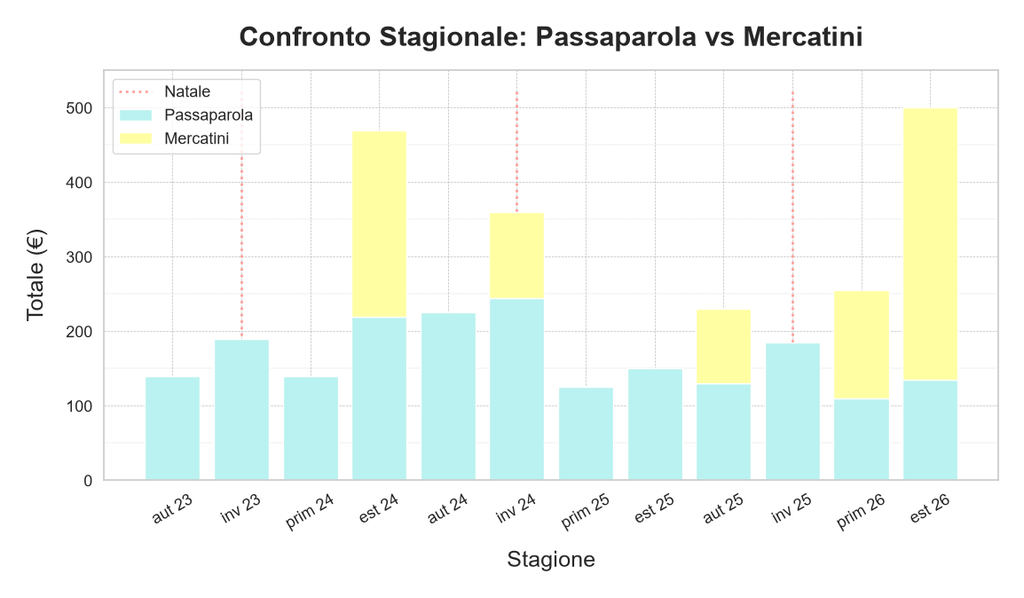

```python
from IPython.display import Image
Image(filename = "Immagini/Passaparola-Mercatini.png")
```

## Il prezzo / ora è aumentato nel tempo?

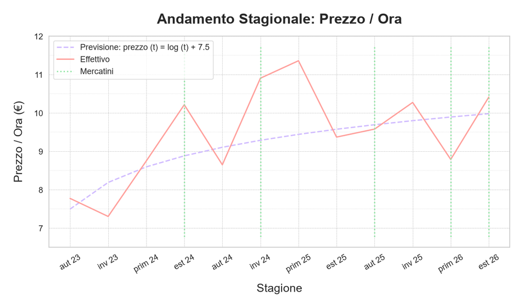

```python
Image(filename = "Immagini/Prezzo-Ora.png")
```

## Quali tipi vendono di più?

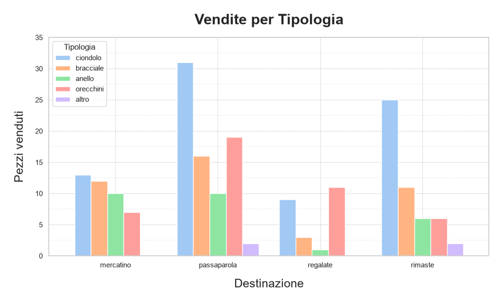

```python
Image(filename = "Immagini/Tipologie.png")
```

## Quanti hanno un disegno originale?

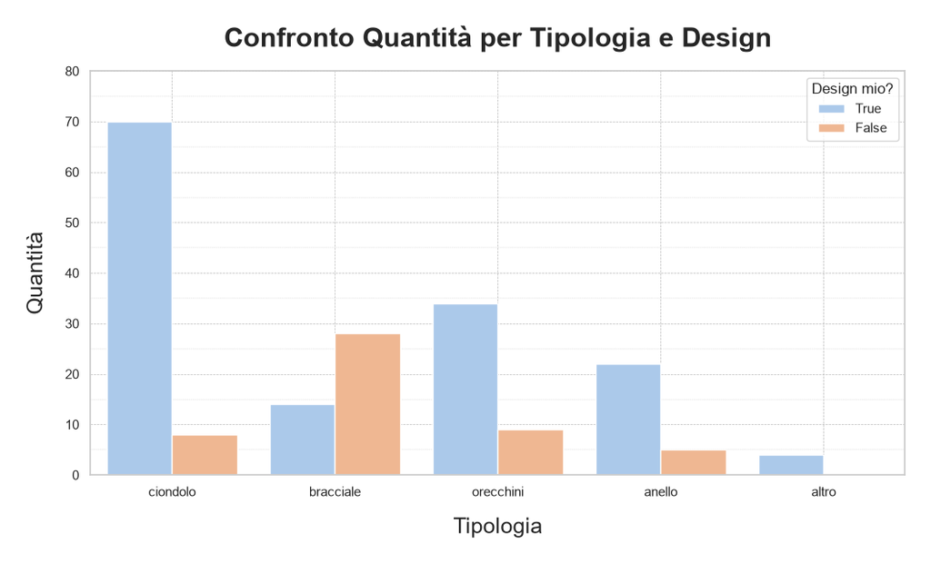

```python
Image(filename = "Immagini/Tipologia-design.png")
```

## Quali sono i tipi più pesanti?

Confronto: presenza di perline e origine del design

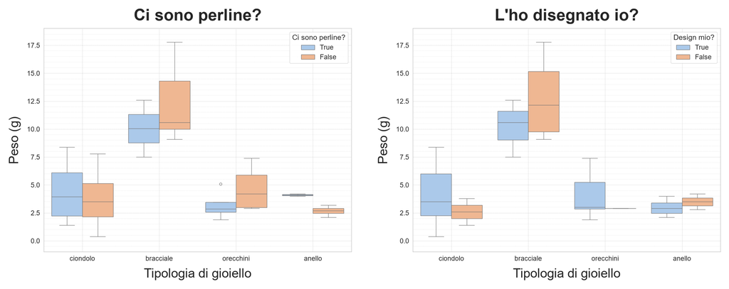

```python
Image(filename = "Immagini/Peso.png")
```

## Il peso è proporzionale alle ore?

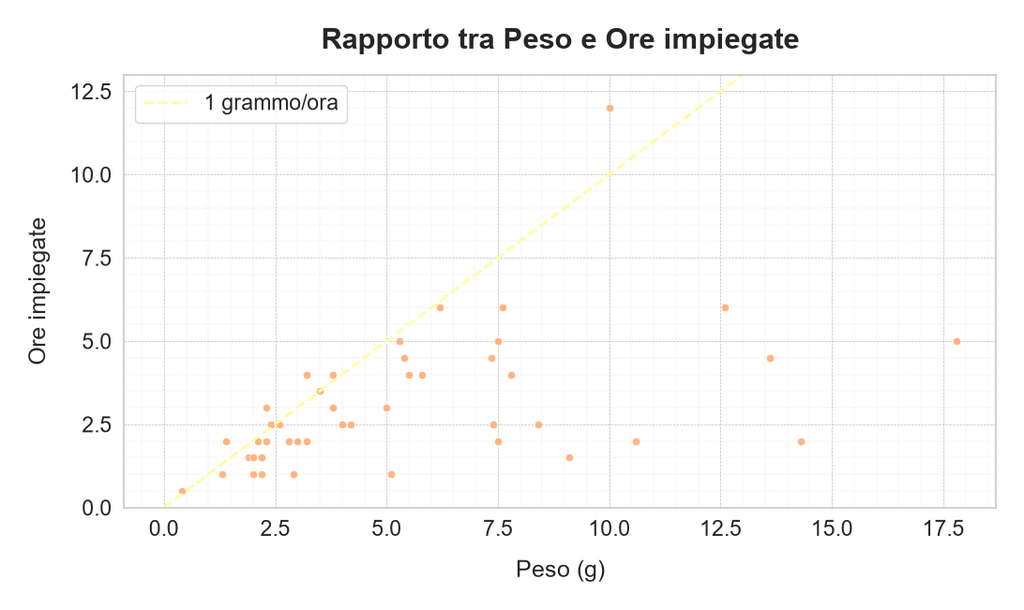

```python
Image(filename = "Immagini/Peso-ore.png")
```

## Meglio più pezzi piccoli o uno grande?

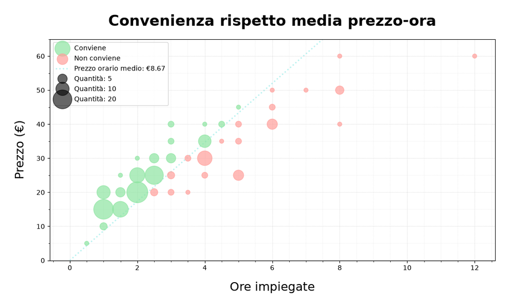

```python
Image(filename = "Media-prezzo-ora.png")
```

# Conclusioni